# Выявление закономерности успешности продаж игр на различных игровых платформах

Чтобы сделать ставку на потенциально популярный продукт и спланировать рекламные кампании, нужно провести глубокий анализ данных о продажах игр за необходимый период времени.

В нашем распоряжении данные о продажах данные до 2016 года. Необходимо проанализировать данные и выявить определяющие успешность игры закономерности, что позволит сделать ставку на потенциально популярный продукт и спланировать рекламные кампании.

# Описание данных

- `Name`— название игры
- `Platform` — платформа
- `Year_of_Release` — год выпуска
- `Genre` — жанр игры
- `NA_sales` — продажи в Северной Америке (миллионы проданных копий)
- `EU_sales` — продажи в Европе (миллионы проданных копий)
- `JP_sales` — продажи в Японии (миллионы проданных копий)
- `Other_sales` — продажи в других странах (миллионы проданных копий)
- `Critic_Score` — оценка критиков (максимум 100)
- `User_Score` — оценка пользователей (максимум 10)
- `Rating` — рейтинг от организации ESRB (англ. Entertainment Software Rating Board). Эта ассоциация определяет рейтинг компьютерных игр и присваивает им подходящую возрастную категорию.

# План работы

**Шаг 1. Загрузка данных**

- Считать CSV-файл с данными с помощью библиотеки pandas и сохранить в датафрейм. Путь к файлу: `/datasets/games.csv`

**Шаг 2. Предобработка данных**

- Заменить названия столбцов.
- Преобразовать данные в нужные типы.
- Обработать пропуски при необходимости.
- Посчитать суммарные продажи во всех регионах и записать их в отдельный столбец.

**Шаг 3. Исследовательский анализ данных**

- Посмотреть, сколько игр выпускалось в разные годы.
- Посмотреть, как менялись продажи по платформам. Выбрать платформы с наибольшими суммарными продажами и построить распределение по годам.
- Взять данные за соответствующий актуальный период. Актуальный период определить в результате исследования предыдущих вопросов. Основной фактор — эти данные помогут построить прогноз на 2017 год.
- Не учитывать в работе данные за предыдущие годы.
- Какие платформы лидируют по продажам, растут или падают? Выбрать несколько потенциально прибыльных платформ.
- Построить график «ящик с усами» по глобальным продажам игр в разбивке по платформам. Описать результат.
- Посмотреть, как влияют на продажи внутри одной популярной платформы отзывы пользователей и критиков. Построить диаграмму рассеяния и посчитать корреляцию между отзывами и продажами. Сформулировать выводы.
- Соотнести выводы с продажами игр на других платформах.
- Посмотреть на общее распределение игр по жанрам. Что можно сказать о самых прибыльных жанрах? Выделяются ли жанры с высокими и низкими продажами?

**Шаг 4. Составление портрета пользователя каждого региона**

Определить для пользователя каждого региона (NA, EU, JP):

- Самые популярные платформы (топ-5).
- Самые популярные жанры (топ-5).
- Влияет ли рейтинг ESRB на продажи в отдельном регионе?

**Шаг 5. Проверка гипотез**

- Средние пользовательские рейтинги платформ Xbox One и PC одинаковые;
- Средние пользовательские рейтинги жанров Action (англ. «действие», экшен-игры) и Sports (англ. «спортивные соревнования») разные.

**Шаг 6. Формулировка общего вывода**

Описать полученные результаты и зафиксировать итоговый вывод проведённого исследования.

### Загрузка данных

На данном шаге нам необходимо загрузить необходимые библиотеки, загрузить и ознакомится с данными.

#### Импортируем необходимые библиотеки

```python
import pandas as pd
import numpy as np
import seaborn as sns
import matplotlib.pyplot as plt
from scipy import stats as st
from scipy.stats import binom, poisson
from math import sqrt
from math import factorial
```

#### Загружаем данные и изучаем общую информацию о данных

```python
try:
    data = pd.read_csv('games.csv')
except:
    data = pd.read_csv('https://code.s3.yandex.net/datasets/games.csv')
```

```python
data.head(10)
```

|  | Name | Platform | Year_of_Release | Genre | NA_sales | EU_sales | JP_sales | Other_sales | Critic_Score | User_Score | Rating |
| --- | --- | --- | --- | --- | --- | --- | --- | --- | --- | --- | --- |
| 0 | Wii Sports | Wii | 2006.0 | Sports | 41.36 | 28.96 | 3.77 | 8.45 | 76.0 | 8 | E |
| 1 | Super Mario Bros. | NES | 1985.0 | Platform | 29.08 | 3.58 | 6.81 | 0.77 | NaN | NaN | NaN |
| 2 | Mario Kart Wii | Wii | 2008.0 | Racing | 15.68 | 12.76 | 3.79 | 3.29 | 82.0 | 8.3 | E |
| 3 | Wii Sports Resort | Wii | 2009.0 | Sports | 15.61 | 10.93 | 3.28 | 2.95 | 80.0 | 8 | E |
| 4 | Pokemon Red/Pokemon Blue | GB | 1996.0 | Role-Playing | 11.27 | 8.89 | 10.22 | 1.00 | NaN | NaN | NaN |
| 5 | Tetris | GB | 1989.0 | Puzzle | 23.20 | 2.26 | 4.22 | 0.58 | NaN | NaN | NaN |
| 6 | New Super Mario Bros. | DS | 2006.0 | Platform | 11.28 | 9.14 | 6.50 | 2.88 | 89.0 | 8.5 | E |
| 7 | Wii Play | Wii | 2006.0 | Misc | 13.96 | 9.18 | 2.93 | 2.84 | 58.0 | 6.6 | E |
| 8 | New Super Mario Bros. Wii | Wii | 2009.0 | Platform | 14.44 | 6.94 | 4.70 | 2.24 | 87.0 | 8.4 | E |
| 9 | Duck Hunt | NES | 1984.0 | Shooter | 26.93 | 0.63 | 0.28 | 0.47 | NaN | NaN | NaN |

```python
data.info()
```

```
<class 'pandas.core.frame.DataFrame'>
RangeIndex: 16715 entries, 0 to 16714
Data columns (total 11 columns):
 #   Column           Non-Null Count  Dtype
---  ------           --------------  -----
 0   Name             16713 non-null  object
 1   Platform         16715 non-null  object
 2   Year_of_Release  16446 non-null  float64
 3   Genre            16713 non-null  object
 4   NA_sales         16715 non-null  float64
 5   EU_sales         16715 non-null  float64
 6   JP_sales         16715 non-null  float64
 7   Other_sales      16715 non-null  float64
 8   Critic_Score     8137 non-null   float64
 9   User_Score       10014 non-null  object
 10  Rating           9949 non-null   object
dtypes: float64(6), object(5)
memory usage: 1.4+ MB
```

**Вывод:** По первичному просмотру данных, мы имеем 16715 строк и 11 колонок. Данные имеют пропущенные значения, а также не все столбцы имеют правильный тип данных.

### Предобработка данных

На данном шаге необходимо: привести названия столбцов к правильному виду, преобразовать данные в нужные типы, обработать пропуски при необходимости, проверить данные на наличие явных и неявных дубликатов, посчитать суммарные продажи во всех регионах и записать их в отдельный столбец.

#### Заменим названия столбцов

```python
data.columns = data.columns.str.lower()
```

#### Переименуем некоторые столбцы

```python
data.rename(columns = {'year_of_release':'year', 'na_sales':'na', 'eu_sales':'eu', 'jp_sales': 'jp', 'other_sales': 'other'}, inplace=True)
```

```python
# Выведем количество пропущенных значений для каждого столбца
data.isna().sum()
```

```
name               2
platform           0
year             269
genre              2
na                 0
eu                 0
jp                 0
other              0
critic_score    8578
user_score      6701
rating          6766
dtype: int64
```

#### Обработаем пропуски в данных

```python
# Избавимся от пропусков в столбце `year`, удалив эти строки
data = data.dropna(subset=['year'])
```

```python
# Избавимся от пропусков в столбце `name` и `genre`
data = data.dropna(subset = ['name', 'genre'])
```

#### Преобразуем данные в нужные типы

```python
data['year'] = data['year'].astype('Int64')
data['critic_score'] = data['critic_score'].astype('Int64')
```

Перед тем как менять тип данных в столбце `user_score`, проверим данные столбца на наличие строк в данных.

```python
data['user_score'].unique()
```

```
array(['8', nan, '8.3', '8.5', '6.6', '8.4', '8.6', '7.7', '6.3', '7.4',
       '8.2', '9', '7.9', '8.1', '8.7', '7.1', '3.4', '5.3', '4.8', '3.2',
       '8.9', '6.4', '7.8', '7.5', '2.6', '7.2', '9.2', '7', '7.3', '4.3',
       '7.6', '5.7', '5', '9.1', '6.5', 'tbd', '8.8', '6.9', '9.4', '6.8',
       '6.1', '6.7', '5.4', '4', '4.9', '4.5', '9.3', '6.2', '4.2', '6',
       '3.7', '4.1', '5.8', '5.6', '5.5', '4.4', '4.6', '5.9', '3.9',
       '3.1', '2.9', '5.2', '3.3', '4.7', '5.1', '3.5', '2.5', '1.9', '3',
       '2.7', '2.2', '2', '9.5', '2.1', '3.6', '2.8', '1.8', '3.8', '0',
       '1.6', '9.6', '2.4', '1.7', '1.1', '0.3', '1.5', '0.7', '1.2',
       '2.3', '0.5', '1.3', '0.2', '0.6', '1.4', '0.9', '1', '9.7'],
      dtype=object)
```

Аббревиатура "tbd" обозначает To Be Determined, то есть "Будет определено", поэтому пока можем заменить значением "nan".

```python
data.loc[data['user_score'] == 'tbd', 'user_score'] = np.nan
```

Теперь можно преобразовать столбец 'user_score' в тип данных float64

```python
data['user_score'] = data['user_score'].astype('float64')
```

#### Проверим данные на наличие неявных дубликатов

Проверим на уникальность столбец `critic_score`

```python
data['critic_score'].unique()
```

```
<IntegerArray>
[  76, <NA>,   82,   80,   89,   58,   87,   91,   61,   97,   95,   77,   88,
   83,   94,   93,   85,   86,   98,   96,   90,   84,   73,   74,   78,   92,
   71,   72,   68,   62,   49,   67,   81,   66,   56,   79,   70,   59,   64,
   75,   60,   63,   69,   50,   25,   42,   44,   55,   48,   57,   29,   47,
   65,   54,   20,   53,   37,   38,   33,   52,   30,   32,   43,   45,   51,
   40,   46,   39,   34,   41,   36,   31,   27,   35,   26,   19,   28,   23,
   24,   21,   17,   13]
Length: 82, dtype: Int64
```

Проверим наличие неявных дубликатов сразу по трем столбцам: Название игры, платформа и год

```python
data[data[['name','platform','year']].duplicated(keep=False)]
```

|  | name | platform | year | genre | na | eu | jp | other | critic_score | user_score | rating |
| --- | --- | --- | --- | --- | --- | --- | --- | --- | --- | --- | --- |
| 604 | Madden NFL 13 | PS3 | 2012 | Sports | 2.11 | 0.22 | 0.0 | 0.23 | 83 | 5.5 | E |
| 16230 | Madden NFL 13 | PS3 | 2012 | Sports | 0.00 | 0.01 | 0.0 | 0.00 | 83 | 5.5 | E |

Избавимся от дубликатов по трем столбцам: Название игры, платформа и год

```python
data = data.drop_duplicates(subset=['name','platform','year'])
```

Проверим на уникальность столбец `rating`

```python
data['rating'].unique()
```

```
array(['E', nan, 'M', 'T', 'E10+', 'K-A', 'AO', 'EC', 'RP'], dtype=object)
```

Пропуски в рейтинге ESRB связаны с тем, что рейтинг ESRB предназначен для маркировки игр для США и Канады. Поэтому другие регионы, скорее используют другую систему рейтинга.

Удалить эти строки с пропускам не можем, так как они составляют треть датасета, поэтому поставим "заглушки".

Расшифруем аббревиатуры рейтингов ESRB:

- E (Everyone) — «Для всех»
- M (Mature) — «Для взрослых»
- T (Teen) — «Подросткам»
- E10+ (Everyone 10 and older) — «Для всех от 10 лет и старше»
- K-A - старый вариант маркировки E (for everyone)
- AO (Adults Only 18+) — «Только для взрослых»
- EC (Early childhood) — «Для детей младшего возраста»
- RP (Rating Pending) — «Рейтинг ожидается»

Заменим K-A на Е, АО на М. Так же заменим пропуски в этом столбце на RP(Рейтинг ожидается).

```python
data.loc[data['rating']=='K-A', 'rating']='E'
data.loc[data['rating']=='AO', 'rating']='M'
data['rating'] = data['rating'].fillna('RP')
#data['rating'].unique()
```

Проверим на уникальность столбец `genre`

```python
data['genre'].unique()
```

```
array(['Sports', 'Platform', 'Racing', 'Role-Playing', 'Puzzle', 'Misc',
       'Shooter', 'Simulation', 'Action', 'Fighting', 'Adventure',
       'Strategy'], dtype=object)
```

Проверим на уникальность столбец `year`

```python
data['year'].unique()
```

```
<IntegerArray>
[2006, 1985, 2008, 2009, 1996, 1989, 1984, 2005, 1999, 2007, 2010, 2013, 2004,
 1990, 1988, 2002, 2001, 2011, 1998, 2015, 2012, 2014, 1992, 1997, 1993, 1994,
 1982, 2016, 2003, 1986, 2000, 1995, 1991, 1981, 1987, 1980, 1983]
Length: 37, dtype: Int64
```

#### Проверим данные на наличие явных дубликатов

```python
data.duplicated().sum()
```

```
0
```

Явных дубликатов не выявлено.

Выведем еще раз общую информацию о данных

```python
data.info()
```

```
<class 'pandas.core.frame.DataFrame'>
Int64Index: 16443 entries, 0 to 16714
Data columns (total 11 columns):
 #   Column        Non-Null Count  Dtype
---  ------        --------------  -----
 0   name          16443 non-null  object
 1   platform      16443 non-null  object
 2   year          16443 non-null  Int64
 3   genre         16443 non-null  object
 4   na            16443 non-null  float64
 5   eu            16443 non-null  float64
 6   jp            16443 non-null  float64
 7   other         16443 non-null  float64
 8   critic_score  7982 non-null   Int64
 9   user_score    7462 non-null   float64
 10  rating        16443 non-null  object
dtypes: Int64(2), float64(5), object(4)
memory usage: 1.5+ MB
```

```python
# Посчитаем суммарные продажи во всех регионах и запишем их в отдельный столбец
data['sales'] = data['na'] + data['eu'] + data['jp'] + data['other']
data['sales']
```

```
0        82.54
1        40.24
2        35.52
3        32.77
4        31.38
         ...
16710     0.01
16711     0.01
16712     0.01
16713     0.01
16714     0.01
Name: sales, Length: 16443, dtype: float64
```

#### Выводы по предобработке данных

По итогам предобработки данных, мы заменили названия столбцов, преобразовали данные в нужные типы, обработали пропуски и посчитали суммарные продажи во всех регионах.

Преобразовали типы данных в столбцах `year` и `user_score`, так как год - целочисленное значение, а оценка пользователей - численное значение с плавающей запятой.

В столбце `year` избавились от пропусков, удалив строки, так как количество таких пропусков не существенно. В столбцах `name` и `genre` избавились от пропусков, удалив эти сторки из датасета (их количество равнялось двум сторкам).

Аббревиатуру в столбце `user_score` "tbd" заменили на значение "nan", так как она обозначает To Be Determined, то есть "Будет определено", но пока неизвестно.

Причины пропусков в столбцах `critic_score`, `user_score`, `rating`, скорее всего, связаны с тем, что многие игры были выпущены в 90-е годы, когда критики еще не совсем добрались до игр, также и пользователи, которые свои отзывы обычно оставляют в соц.сетях. Рейтинги ESRB начали происваивать играм с 1994 года, поэтому пропуски рейтингов у игр до 1994 неизбежны.

```python
# Посмотрим, что у нас осталось
list_c = ['name', 'platform', 'year', 'genre', 'critic_score', 'user_score', 'rating']
print(data.info())
for col_l in list_c:
  print('-'* 25)
  print(col_l, data[col_l].sort_values().unique())
  print(col_l,' : кол-во 0', data[data[col_l] == 0][col_l].count(),
        ', процент 0', round(data[data[col_l] == 0][col_l].count()/len(data)*100, 2),'%')
  print(col_l,': кол-во NaN',data[col_l].isna().sum(),
        ', процент NaN', round(data[col_l].isna().mean()*100,2),'%')
```

```
<class 'pandas.core.frame.DataFrame'>
Int64Index: 16443 entries, 0 to 16714
Data columns (total 12 columns):
 #   Column        Non-Null Count  Dtype
---  ------        --------------  -----
 0   name          16443 non-null  object
 1   platform      16443 non-null  object
 2   year          16443 non-null  Int64
 3   genre         16443 non-null  object
 4   na            16443 non-null  float64
 5   eu            16443 non-null  float64
 6   jp            16443 non-null  float64
 7   other         16443 non-null  float64
 8   critic_score  7982 non-null   Int64
 9   user_score    7462 non-null   float64
 10  rating        16443 non-null  object
 11  sales         16443 non-null  float64
dtypes: Int64(2), float64(6), object(4)
memory usage: 2.2+ MB
None
-------------------------
name [' Beyblade Burst' ' Fire Emblem Fates' " Frozen: Olaf's Quest" ...
 'uDraw Studio' 'uDraw Studio: Instant Artist'
 '¡Shin Chan Flipa en colores!']
name  : кол-во 0 0 , процент 0 0.0 %
name : кол-во NaN 0 , процент NaN 0.0 %
-------------------------
platform ['2600' '3DO' '3DS' 'DC' 'DS' 'GB' 'GBA' 'GC' 'GEN' 'GG' 'N64' 'NES' 'NG'
 'PC' 'PCFX' 'PS' 'PS2' 'PS3' 'PS4' 'PSP' 'PSV' 'SAT' 'SCD' 'SNES' 'TG16'
 'WS' 'Wii' 'WiiU' 'X360' 'XB' 'XOne']
platform  : кол-во 0 0 , процент 0 0.0 %
platform : кол-во NaN 0 , процент NaN 0.0 %
-------------------------
year <IntegerArray>
[1980, 1981, 1982, 1983, 1984, 1985, 1986, 1987, 1988, 1989, 1990, 1991, 1992,
 1993, 1994, 1995, 1996, 1997, 1998, 1999, 2000, 2001, 2002, 2003, 2004, 2005,
 2006, 2007, 2008, 2009, 2010, 2011, 2012, 2013, 2014, 2015, 2016]
Length: 37, dtype: Int64
year  : кол-во 0 0 , процент 0 0.0 %
year : кол-во NaN 0 , процент NaN 0.0 %
```

[output cut: 15 more lines]

```
critic_score  : кол-во 0 0 , процент 0 0.0 %
critic_score : кол-во NaN 8461 , процент NaN 51.46 %
-------------------------
user_score [0.  0.2 0.3 0.5 0.6 0.7 0.9 1.  1.1 1.2 1.3 1.4 1.5 1.6 1.7 1.8 1.9 2.
 2.1 2.2 2.3 2.4 2.5 2.6 2.7 2.8 2.9 3.  3.1 3.2 3.3 3.4 3.5 3.6 3.7 3.8
 3.9 4.  4.1 4.2 4.3 4.4 4.5 4.6 4.7 4.8 4.9 5.  5.1 5.2 5.3 5.4 5.5 5.6
 5.7 5.8 5.9 6.  6.1 6.2 6.3 6.4 6.5 6.6 6.7 6.8 6.9 7.  7.1 7.2 7.3 7.4
 7.5 7.6 7.7 7.8 7.9 8.  8.1 8.2 8.3 8.4 8.5 8.6 8.7 8.8 8.9 9.  9.1 9.2
 9.3 9.4 9.5 9.6 9.7 nan]
user_score  : кол-во 0 1 , процент 0 0.01 %
user_score : кол-во NaN 8981 , процент NaN 54.62 %
-------------------------
rating ['E' 'E10+' 'EC' 'M' 'RP' 'T']
rating  : кол-во 0 0 , процент 0 0.0 %
rating : кол-во NaN 0 , процент NaN 0.0 %
```

### Исследовательский анализ данных

На данном шаге необходимо рассмотреть следующие вопросы:

- Посмотреть, сколько игр выпускалось в разные годы. Важны ли данные за все периоды?
- Посмотреть, как менялись продажи по платформам. Выбрать платформы с наибольшими суммарными продажами и построить распределение по годам. За какой характерный срок появляются новые и исчезают старые платформы?
- Взять данные за соответствующий актуальный период. Актуальный период определить в результате исследования предыдущих вопросов.Основной фактор — эти данные помогут построить прогноз на 2017 год.
- Какие платформы лидируют по продажам, растут или падают? Выбрать несколько потенциально прибыльных платформ.
- Построить график «ящик с усами» по глобальным продажам игр в разбивке по платформам. Описать результат.
- Посмотреть, как влияют на продажи внутри одной популярной платформы отзывы пользователей и критиков. Построить диаграмму рассеяния и посчитать корреляцию между отзывами и продажами. Сформулировать выводы.
- Соотнести выводы с продажами игр на других платформах.
- Посмотреть на общее распределение игр по жанрам. Что можно сказать о самых прибыльных жанрах? Выделяются ли жанры с высокими и низкими продажами?

#### Посмотрим, сколько игр выпускалось в разные годы и важны ли данные за все периоды

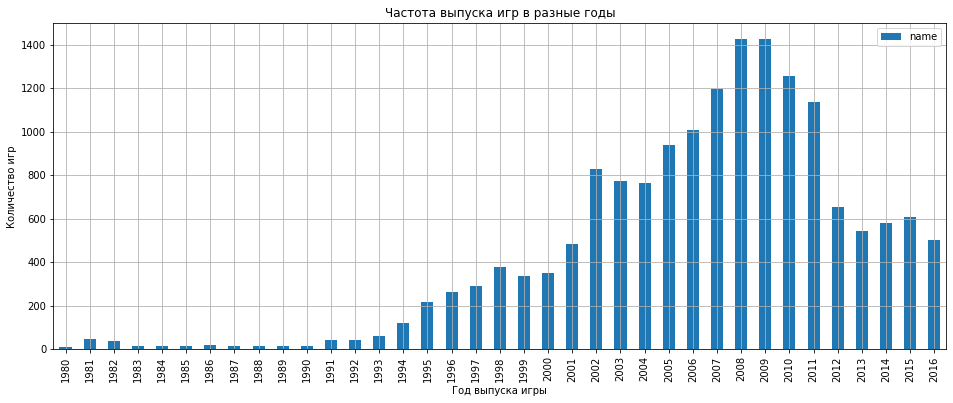

```python
#data['year'].value_counts().plot(kind='bar', grid=True, title='Частота выпуска игр в разные годы', ylabel = 'Количество игр', xlabel = 'Год выпуска игры', figsize=(16,6));
data.pivot_table(index='year', values='name', aggfunc='count').plot(kind='bar', grid=True, title='Частота выпуска игр в разные годы', ylabel = 'Количество игр', xlabel = 'Год выпуска игры', figsize=(16,6));
```

По столбчатой диаграмме видно, что наиболее часто игры выпускались в 2008 и 2009 годах, реже всего игры выпускались начиная с 1980 по 1993 включительно.

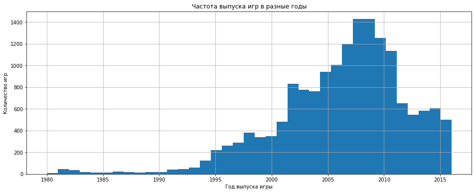

```python
data['year'].plot(kind='hist', grid=True, title='Частота выпуска игр в разные годы', bins=37, figsize=(16,6));
plt.xlabel('Год выпуска игры')
plt.ylabel('Количество игр')
plt.show()
```

- По гистаграмме также видно, что наиболее часто игры выпускались в период 2008-2009 гг.
- Период с 1980 по 1994 не так активен в выпуске игр, эти года нам не сильно будут важны при дальнейшем анализе.

#### Посмотрим, как менялись продажи по платформам

```python
sales_platforms = data.pivot_table(index = 'platform', values = 'sales', aggfunc = {'sum'}).sort_values('sum', ascending = False)
sales_platforms = sales_platforms.rename(columns={'sum':'sales_sum'})
sales_platforms = sales_platforms.reset_index()
sales_platforms
```

|  | platform | sales_sum |
| --- | --- | --- |
| 0 | PS2 | 1233.56 |
| 1 | X360 | 961.24 |
| 2 | PS3 | 931.33 |
| 3 | Wii | 891.18 |
| 4 | DS | 802.78 |
| 5 | PS | 727.58 |
| 6 | PS4 | 314.14 |
| 7 | GBA | 312.88 |
| 8 | PSP | 289.53 |
| 9 | 3DS | 257.81 |
| 10 | PC | 255.76 |
| 11 | GB | 254.43 |
| 12 | XB | 251.57 |
| 13 | NES | 251.05 |
| 14 | N64 | 218.01 |
| 15 | SNES | 200.04 |
| 16 | GC | 196.73 |
| 17 | XOne | 159.32 |
| 18 | 2600 | 86.48 |
| 19 | WiiU | 82.19 |
| 20 | PSV | 53.81 |
| 21 | SAT | 33.59 |
| 22 | GEN | 28.35 |
| 23 | DC | 15.95 |
| 24 | SCD | 1.86 |
| 25 | NG | 1.44 |
| 26 | WS | 1.42 |
| 27 | TG16 | 0.16 |
| 28 | 3DO | 0.10 |
| 29 | GG | 0.04 |
| 30 | PCFX | 0.03 |

Выделим топ 10 с наибольшими суммарными продажами и построим диаграмму

```python
top10_sales_platforms = sales_platforms.iloc[0:10]
```

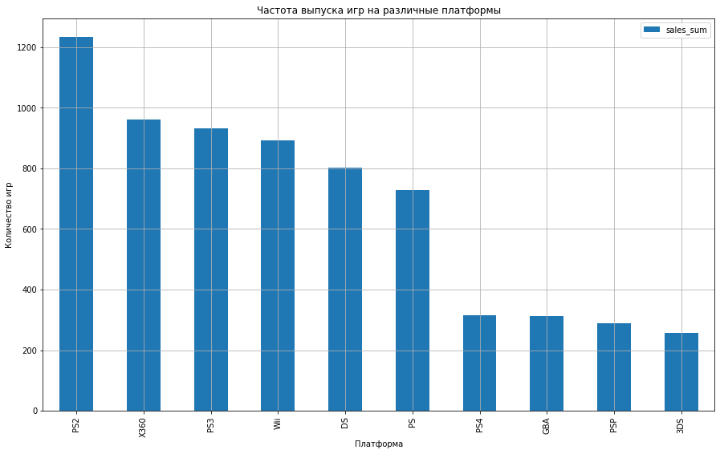

```python
top10_sales_platforms.plot(x='platform', y='sales_sum', kind='bar', grid=True, title='Частота выпуска игр на различные платформы', ylabel = 'Количество игр', xlabel = 'Платформа', figsize=(15,9));
```

Построим далее распределение по годам, чтобы понять в какие годы какая платформа была популярна для выпуска игр.

#### Посмотрим, как менялись продажи по платформам

Построим распределение по годам

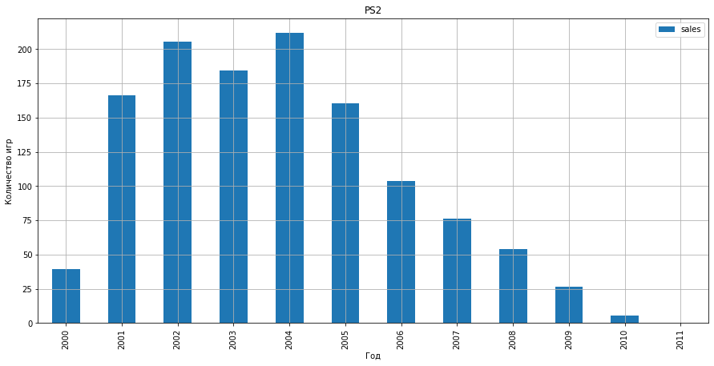

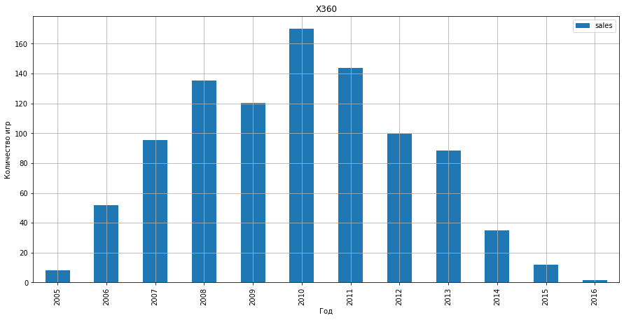

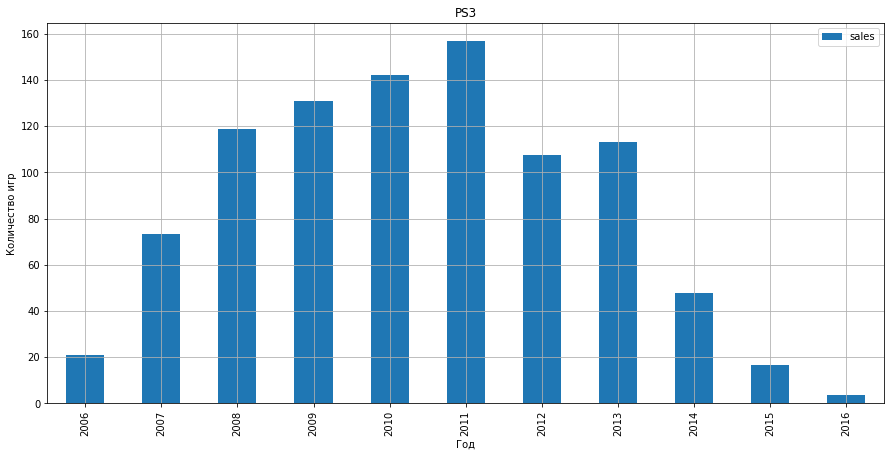

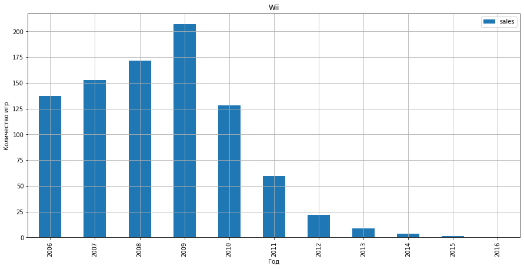

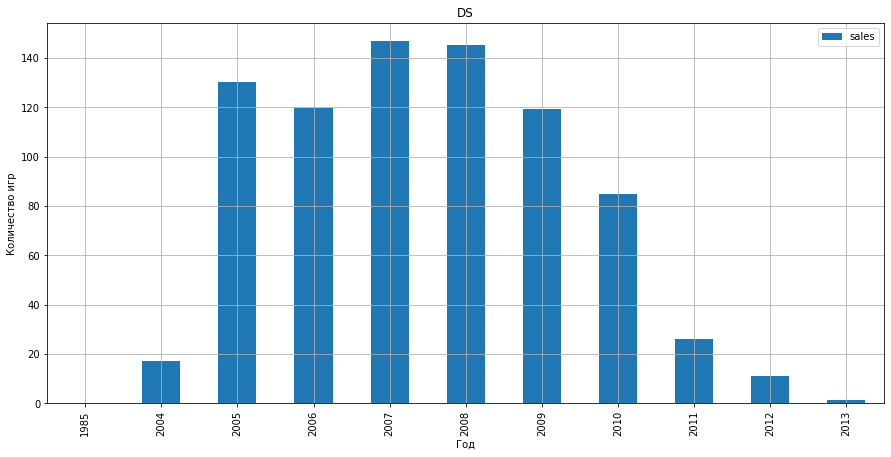

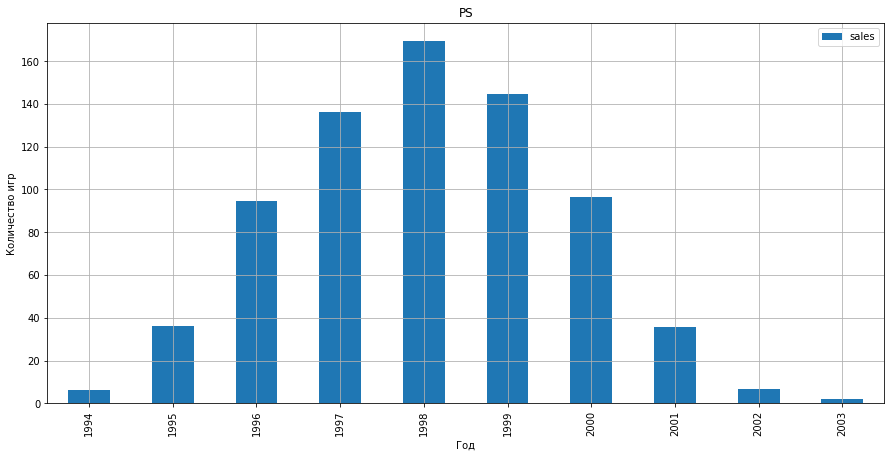

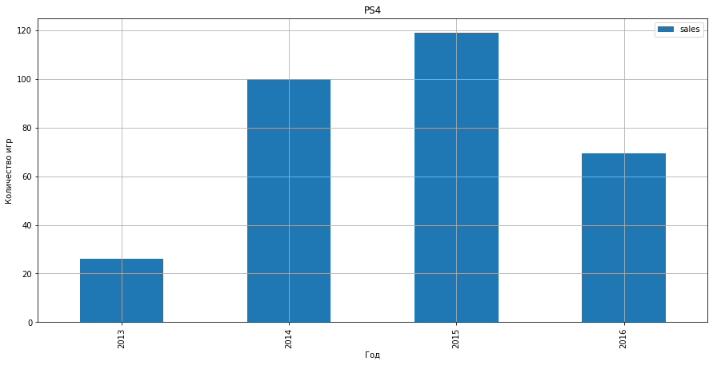

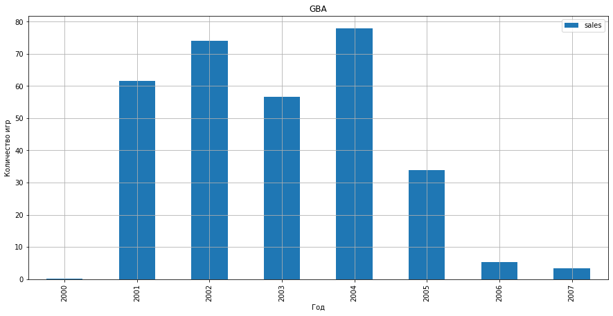

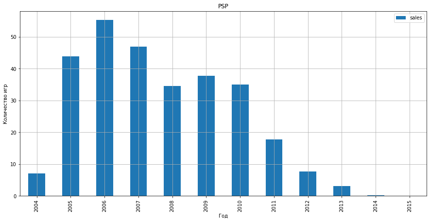

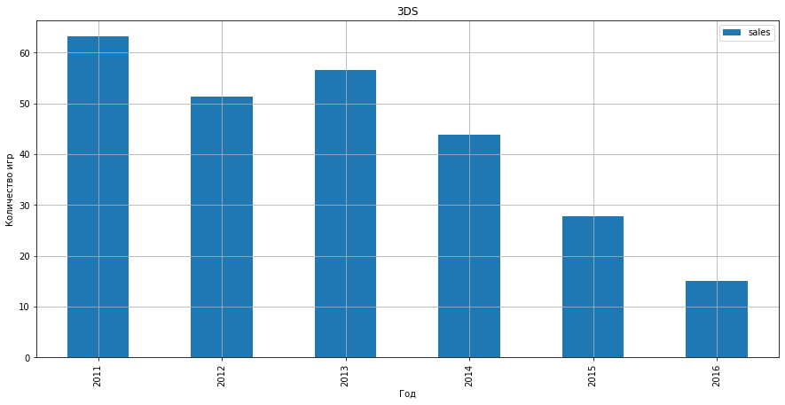

```python
for platform in top10_sales_platforms['platform']:
    data[data['platform'] == platform].pivot_table(index = 'year', values = 'sales', aggfunc = 'sum').plot(kind='bar', grid=True, ylabel = 'Количество игр', xlabel = 'Год', figsize=(15,7))
    plt.title(platform)
```

**По построенным диаграммам можно выделить следующее:**

- Платформа "PS2" лидировала по продажам в период 2002-2004 гг.
- Платформа "Х360" лидировала по продажам в период 2010-2011 гг.
- Платформа "PS3" лидировала по продажам в период 2009-2011 гг.
- Платформа "Wii" лидировала по продажам в период 2008-2009 гг.
- Платформа "DS" лидировала по продажам в период 2007-2008 гг.
- Платформа "PS" лидировала по продажам в период 1997-1999 гг.
- Платформа "PS4" лидировала по продажам в период 2014-2015 гг.
- Платформа "GBA" лидировала по продажам в период 2001-2004 гг.
- Платформа "PSP" лидировала по продажам в период 2005-2007 гг.
- Платформа "3DS" лидировала по продажам в период 2011-2013 гг.

#### Определим средний срок жизни платформы и актуальный период для прогноза продаж

```python
term_platform = data.pivot_table(index='platform', values='year', aggfunc=['min', 'max']).reset_index()
print((term_platform['max'] - term_platform['min'] + 1).median())
```

```
year    7.0
dtype: float64
```

*Средний срок жизни платформы составляет 7 лет. Пик по продажам платформы, судя по диаграммам обычно длится 4-5 лет.*

**Актуальным периодом для прогноза продаж на 2017 год можно считать 2013-2016 гг.**

#### Определим какие платформы лидируют по продажам, растут или падают

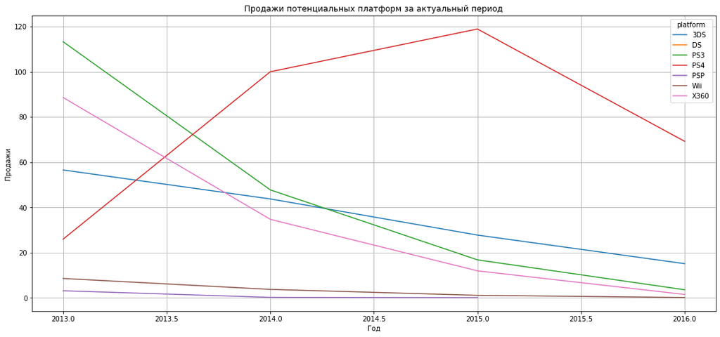

```python
actual_period = data.query('year>=2013')
actual_period.query('platform in @top10_sales_platforms["platform"]').pivot_table(index='year', columns='platform', values = 'sales', aggfunc = 'sum').plot(grid=True, title='Продажи потенциальных платформ за актуальный период', ylabel = 'Продажи', xlabel = 'Год', figsize=(18,8));
```

#### Построим график «ящик с усами» по глобальным продажам игр в разбивке по платформам

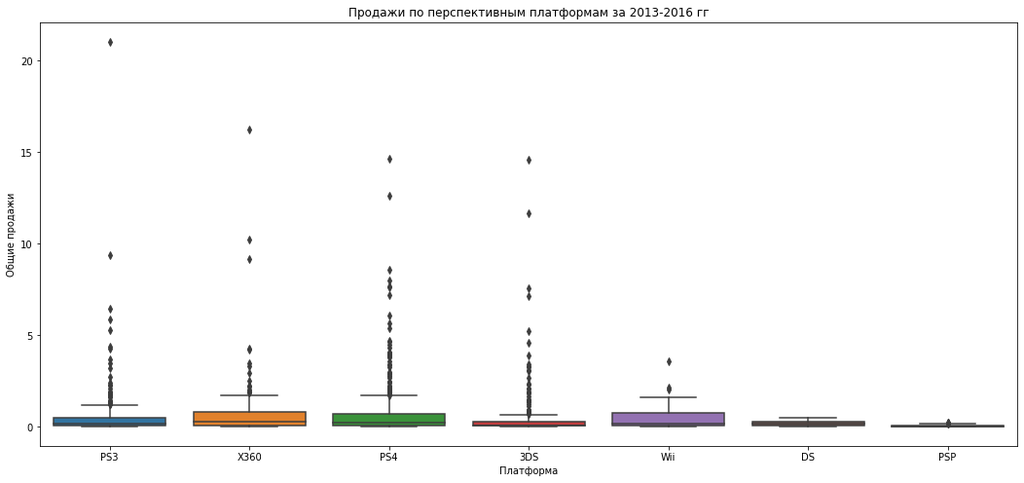

```python
# actual_period.pivot_table(index = 'name', columns = 'platform', values = 'sales', aggfunc = 'sum').plot(kind='box', ylim = (0, 2), title='Ящик с усами', ylabel = 'Глобальные продажи', figsize=(18,8));
promising_platform = actual_period.query('platform in @top10_sales_platforms["platform"]')
plt.figure(figsize=(18, 8))
(sns.boxplot(data=promising_platform, x='platform', y='sales')
    .set(title = 'Продажи по перспективным платформам за 2013-2016 гг',
         xlabel = 'Платформа',
         ylabel = 'Общие продажи'))
         #ylim=(0, 2)))
plt.show();
```

Далее построим эту диаграмму, только в масштабированном формате, чтобы крупнее отразить боксплоты, вантили и медианы.

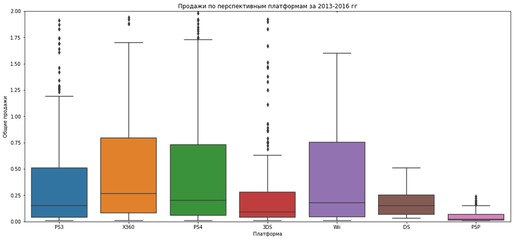

```python
plt.figure(figsize=(18, 8))
(sns.boxplot(data=promising_platform, x='platform', y='sales')
    .set(title = 'Продажи по перспективным платформам за 2013-2016 гг',
         xlabel = 'Платформа',
         ylabel = 'Общие продажи',
         ylim=(0, 2)))
plt.show();
```

Исходя из графиков видно, что лидируют по продажам платформы PS3, PS4, X360, Wii.

#### Посмотрим, как влияют на продажи внутри одной популярной платформы отзывы пользователей и критиков

Построим диаграмму рассеяния и посчитайте корреляцию между отзывами и продажами

##### Влияние отзывов пользователей и критиков на продажу игр платформы PS4

|  | critic_score | user_score | sales |
| --- | --- | --- | --- |
| critic_score | 1.000000 | 0.557654 | 0.406568 |
| user_score | 0.557654 | 1.000000 | -0.031957 |
| sales | 0.406568 | -0.031957 | 1.000000 |

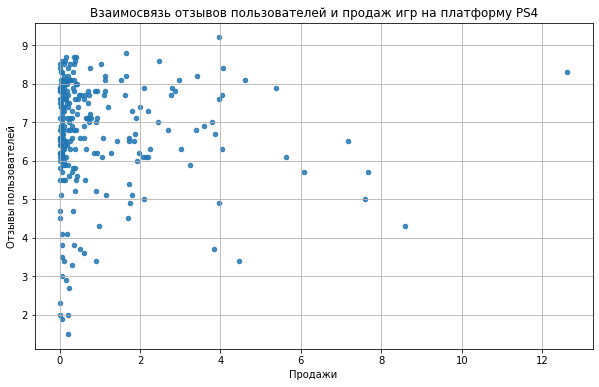

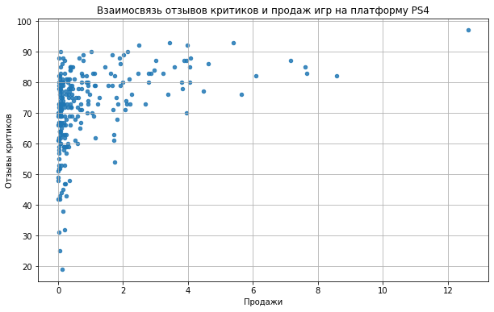

```python
PS4 = actual_period.query('platform=="PS4"')
PS4_corr = PS4[['critic_score','user_score', 'sales']].corr()
display(PS4_corr)
PS4.plot(y='user_score', x='sales', title = 'Взаимосвязь отзывов пользователей и продаж игр на платформу PS4', ylabel = 'Отзывы пользователей', xlabel = 'Продажи', kind='scatter', alpha=0.85, grid=True, figsize=(10, 6));
PS4.plot(y='critic_score', x='sales', title = 'Взаимосвязь отзывов критиков и продаж игр на платформу PS4', ylabel = 'Отзывы критиков', xlabel = 'Продажи', kind='scatter', alpha=0.85, grid=True, figsize=(10, 6));
```

**Внутри платформы РS4 отзывы критиков влияют на продажи, наблюдается положительная взаимосвязь, в то время как отзывы пользователей практически не влияют на продажи - взаимосвяь отрицательная и близка к нулу.**

##### Влияние отзывов пользователей и критиков на продажу игр платформы PC

|  | critic_score | user_score | sales |
| --- | --- | --- | --- |
| critic_score | 1.000000 | 0.429562 | 0.196030 |
| user_score | 0.429562 | 1.000000 | -0.093842 |
| sales | 0.196030 | -0.093842 | 1.000000 |

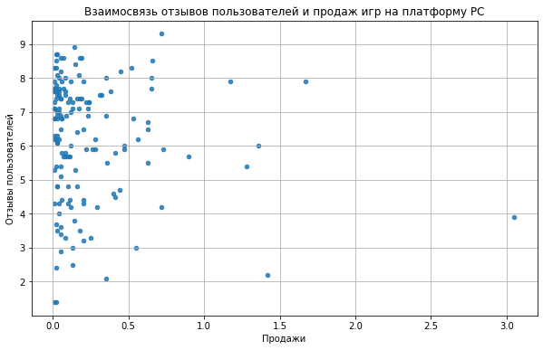

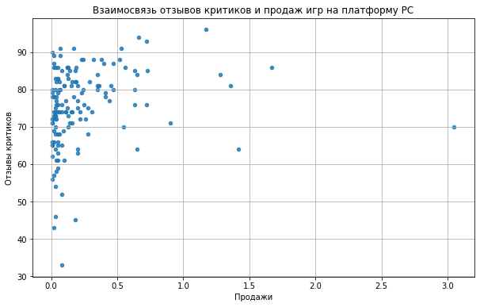

```python
PC = actual_period.query('platform=="PC"')
PC_corr = PC[['critic_score','user_score', 'sales']].corr()
display(PC_corr)
PC.plot(y='user_score', x='sales', title = 'Взаимосвязь отзывов пользователей и продаж игр на платформу PC', ylabel = 'Отзывы пользователей', xlabel = 'Продажи', kind='scatter', alpha=0.85, grid=True, figsize=(10, 6));
PC.plot(y='critic_score', x='sales', title = 'Взаимосвязь отзывов критиков и продаж игр на платформу PC', ylabel = 'Отзывы критиков', xlabel = 'Продажи', kind='scatter', alpha=0.85, grid=True, figsize=(10, 6));
```

**Внутри платформы РС отзывы критиков влияют не существенно на продажи, но положительная взаимосвязь наблюдается, в то время как отзывы пользователей практически не влияют на продажи - взаимосвяь отрицательная и близка к нулу.**

##### Влияние отзывов пользователей и критиков на продажу игр платформы X360

|  | critic_score | user_score | sales |
| --- | --- | --- | --- |
| critic_score | 1.000000 | 0.520946 | 0.350345 |
| user_score | 0.520946 | 1.000000 | -0.011742 |
| sales | 0.350345 | -0.011742 | 1.000000 |

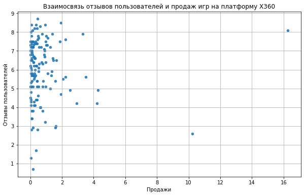

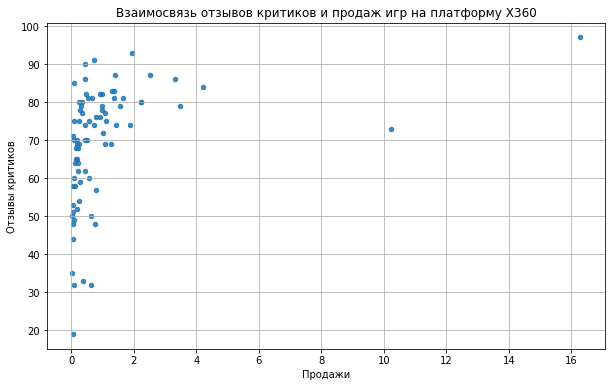

```python
X360 = actual_period.query('platform=="X360"')
X360_corr = X360[['critic_score','user_score', 'sales']].corr()
display(X360_corr)
X360.plot(y='user_score', x='sales', title = 'Взаимосвязь отзывов пользователей и продаж игр на платформу X360', ylabel = 'Отзывы пользователей', xlabel = 'Продажи', kind='scatter', alpha=0.85, grid=True, figsize=(10, 6));
X360.plot(y='critic_score', x='sales', title = 'Взаимосвязь отзывов критиков и продаж игр на платформу X360', ylabel = 'Отзывы критиков', xlabel = 'Продажи', kind='scatter', alpha=0.85, grid=True, figsize=(10, 6));
```

**Внутри платформы X360 отзывы критиков влияют на продажи, наблюдается положительная взаимосвязь, в то время как отзывы пользователей практически не влияют на продажи - взаимосвяь отрицательная и близка к нулу.**

##### Влияние отзывов пользователей и критиков на продажу игр платформы PS3

|  | critic_score | user_score | sales |
| --- | --- | --- | --- |
| critic_score | 1.000000 | 0.520946 | 0.350345 |
| user_score | 0.520946 | 1.000000 | -0.011742 |
| sales | 0.350345 | -0.011742 | 1.000000 |

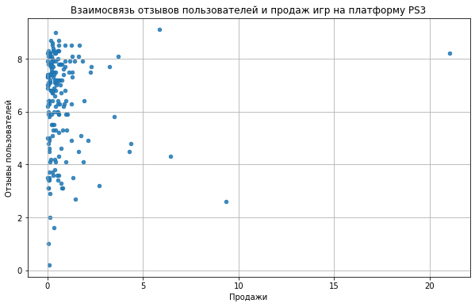

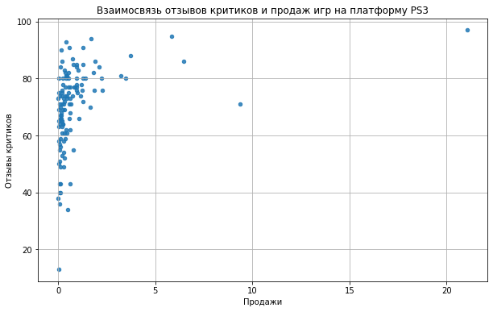

```python
PS3 = actual_period.query('platform=="PS3"')
PS3_corr = X360[['critic_score','user_score', 'sales']].corr()
display(PS3_corr)
PS3.plot(y='user_score', x='sales', title = 'Взаимосвязь отзывов пользователей и продаж игр на платформу PS3', ylabel = 'Отзывы пользователей', xlabel = 'Продажи', kind='scatter', alpha=0.85, grid=True, figsize=(10, 6));
PS3.plot(y='critic_score', x='sales', title = 'Взаимосвязь отзывов критиков и продаж игр на платформу PS3', ylabel = 'Отзывы критиков', xlabel = 'Продажи', kind='scatter', alpha=0.85, grid=True, figsize=(10, 6));
```

##### Влияние отзывов пользователей и критиков на продажу игр платформы Wii

|  | critic_score | user_score | sales |
| --- | --- | --- | --- |
| critic_score | NaN | NaN | NaN |
| user_score | NaN | 1.000000 | 0.682942 |
| sales | NaN | 0.682942 | 1.000000 |

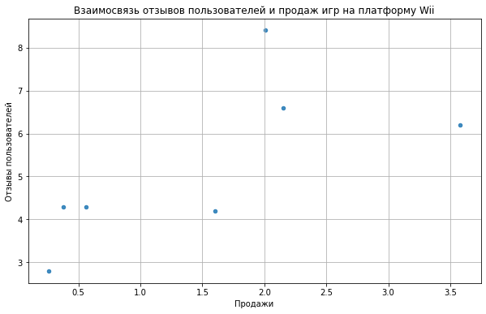

[figure not shown]

```python
Wii = actual_period.query('platform=="Wii"')
Wii_corr = Wii[['critic_score','user_score', 'sales']].corr()
display(Wii_corr)
Wii.plot(y='user_score', x='sales', title = 'Взаимосвязь отзывов пользователей и продаж игр на платформу Wii', ylabel = 'Отзывы пользователей', xlabel = 'Продажи', kind='scatter', alpha=0.85, grid=True, figsize=(10, 6));
Wii.plot(y='critic_score', x='sales', title = 'Взаимосвязь отзывов критиков и продаж игр на платформу Wii', ylabel = 'Отзывы критиков', xlabel = 'Продажи', kind='scatter', alpha=0.85, grid=True, figsize=(10, 6));
```

**Вывод по влиянии продаж внутри одной популярной платформы на отзывы пользователей и критиков:**

- существенную взаимосвязь стоит отметить между отзывами критиков и продажами внутри одной популярной платформы;
- наблюдается взаимосвязь между отзывами критиков и отзывами пользователей;
- наблюдается достаточно слабая взаимосвязь между отзывами пользователей и продажами внутри одной популярной платформы.

##### Посмотрим на общее распределение игр по жанрам

Необходимо исследовать какие жанры относятся к прибыльным и выделяются ли жанры с высокими и низкими продажами

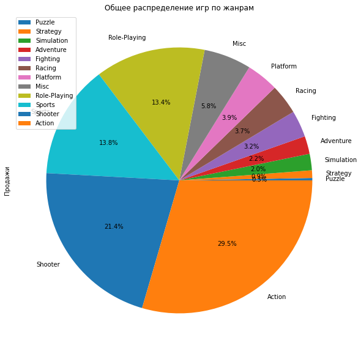

```python
actual_period.pivot_table(index = 'genre', values = 'sales', aggfunc = 'sum').sort_values('sales').plot(kind='pie', y = 'sales', ylabel = 'Продажи', title = 'Общее распределение игр по жанрам', autopct='%1.1f%%', figsize=(10,10));
```

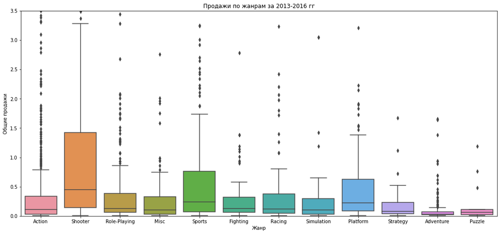

```python
plt.figure(figsize=(18, 8))
(sns.boxplot(data=actual_period, x='genre', y='sales')
    .set(title = 'Продажи по жанрам за 2013-2016 гг',
         xlabel = 'Жанр',
         ylabel = 'Общие продажи',
         ylim=(0, 3.5)))
plt.show();
```

По круговой диаграмме наиболее прибыльный жанр игр - Action, затем идет Shooter и Sports. Наименее прибыльный жанр - Puzzle.

По диаграмме размаха, стоит отметить следующие жанры: Shooter, Sports и Platform. Наименее прибыльный жанр - Adventure. По сравнению с жанром Puzzle, который по круговой диаграмме наименее прибыльный, Adventure имеет медиану ниже, но имеет больше выбросов.

Медиана продаж жанра Shooter выше остальных жанров, что говорит о прибыльности игр данного жанра.